# guion09-2.qmd

```r
library(phangorn)
mtdna <- read.phyDat('../../data/mtDNA.fasta', format = 'fasta')
glance(mtdna)
```

```
  nseq nchar unique_site_pattern parsimony_informative_sites const_sites
1   42 16603                 974                        2047       13482
```

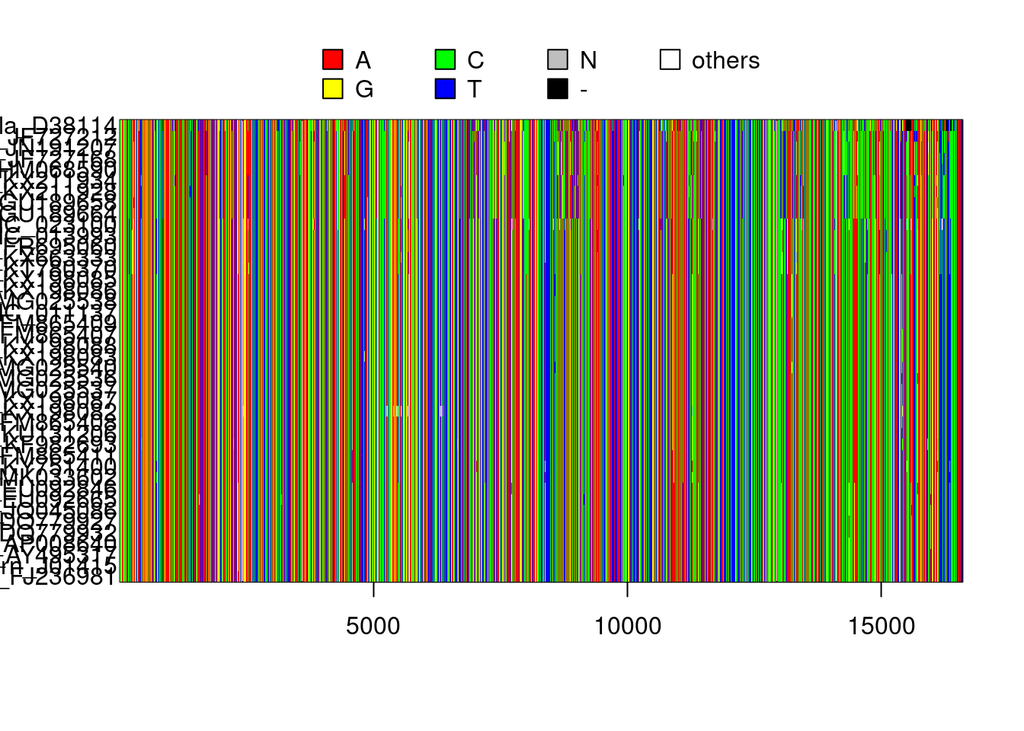

```r
image(mtdna)
```

```r
modelos <- modelTest(mtdna,
    control = pml.control(trace = 0))
```

¿Puedes confirmar el número de secuencias? ¿Qué longitud tiene el alineamiento? ¿Qué función usarías para extraer los nombres de las secuencias? Son 42 secuencias, compuestas por 16603 bases (lo vemos en nchar, número de caracteres). Para ver los nombres utilizamos “names(mtdna)”

##Árboles basados en distancias Vamos a hacer árboles NJ y UPGMA, que son métodos basados en distancias, por lo que hay que calcular primero las distancias.

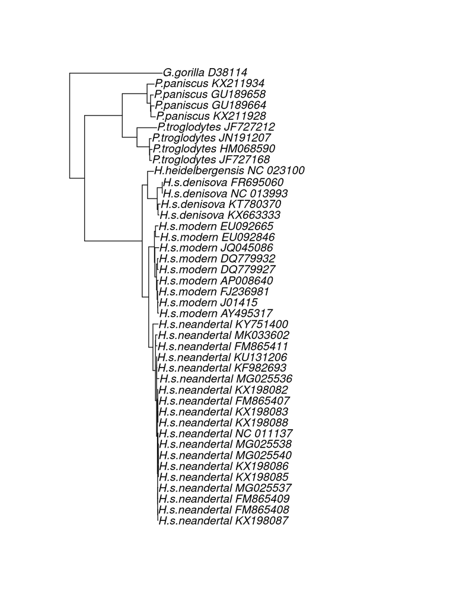

```r
distancias <- dist.ml(mtdna, model = 'F81')
mt_nj    <- NJ(distancias)
mt_upgma <- upgma(distancias)
plot(midpoint(mt_nj))
```

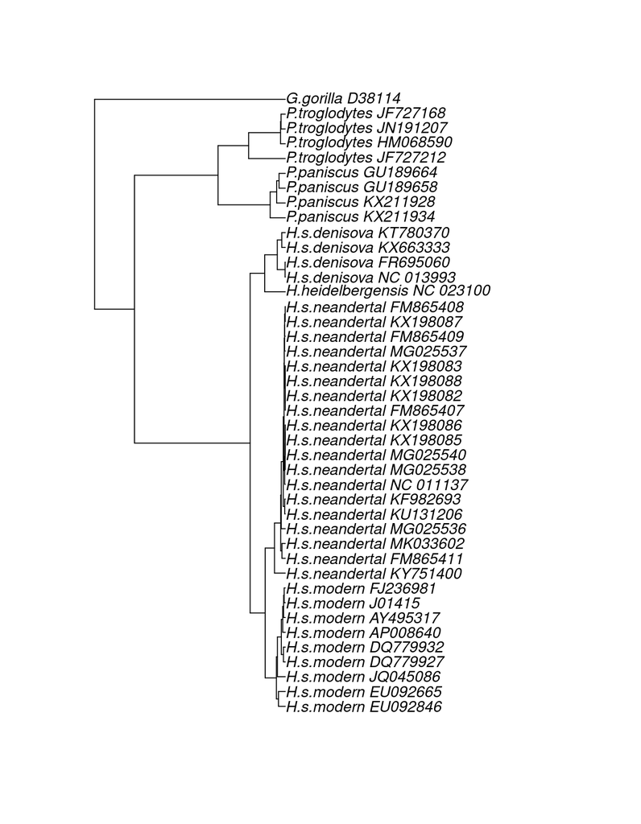

```r
plot(midpoint(mt_upgma))
```

```r
str(mt_nj)
```

```
List of 4
 $ edge       : int [1:81, 1:2] 44 44 54 54 53 53 52 52 51 51 ...
 $ edge.length: num [1:81] 1.97e-04 2.26e-04 -4.37e-08 4.37e-08 8.51e-08 ...
 $ tip.label  : chr [1:42] "G.gorilla_D38114" "P.troglodytes_JF727212" "P.troglodytes_JN191207" "P.troglodytes_JF727168" ...
 $ Nnode      : int 40
 - attr(*, "class")= chr "phylo"
 - attr(*, "order")= chr "postorder"
```

- ¿De qué clase son los objetos mt_nj y mt_upgma? Son árboles filogenéticos (phylo).
- Consulta la estructura de estos objetos (str(mt_nj)).
- Represéntalos gráficamente (plot(mt_nj)) y consulta la ayuda de la función plot.phylo() para saber qué opciones de representación gráfica tienes.

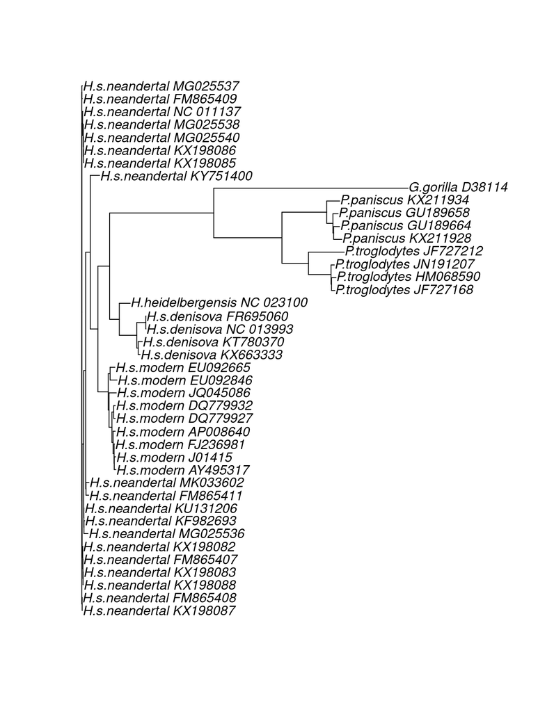

```r
plot(mt_nj) #no ultramétrico
```

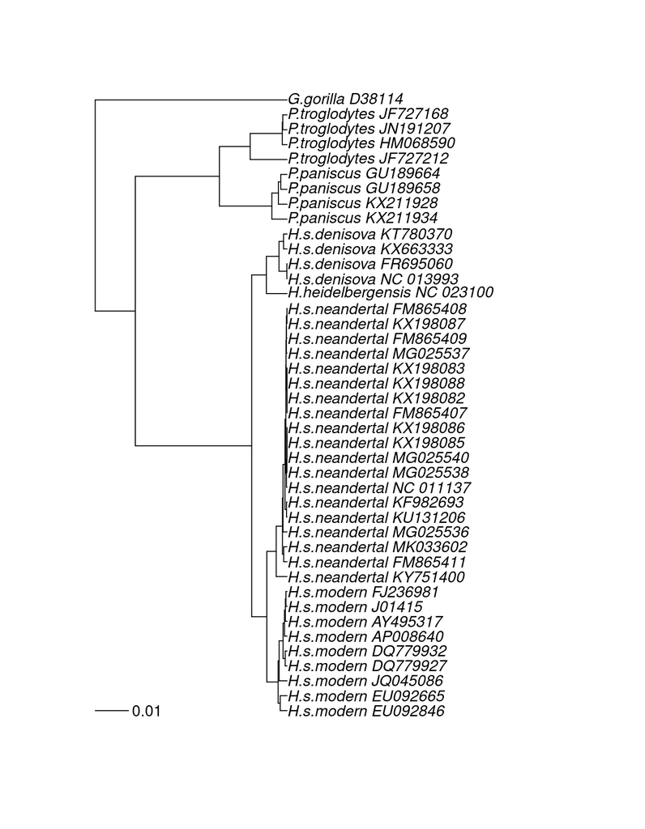

```r
plot(midpoint(mt_upgma)) #ultramétrico
add.scale.bar()
```

Podemos representar distintos tipos de filogenia: filograma, cladogram, fan, unrooted (sin raíz), radial, tidy. - Para qué sirven las funciones add.scale.bar() y axisPhylo()? add.scale.bar sirve para añadir una escala temporal en horizontal para conocer la escala de la longitud de las ramas, pone una unidad de medida asociada a una longitud de rama de árbol. axisPhylo sirve para añadir escala a lo largo de todo el arbol.

## Enraizar árbol

Podemos escoger el nodo en el que sabemos que está el outgroup, si lo conocemos. Para identificar el nodo interno utilizamos nodelabels():

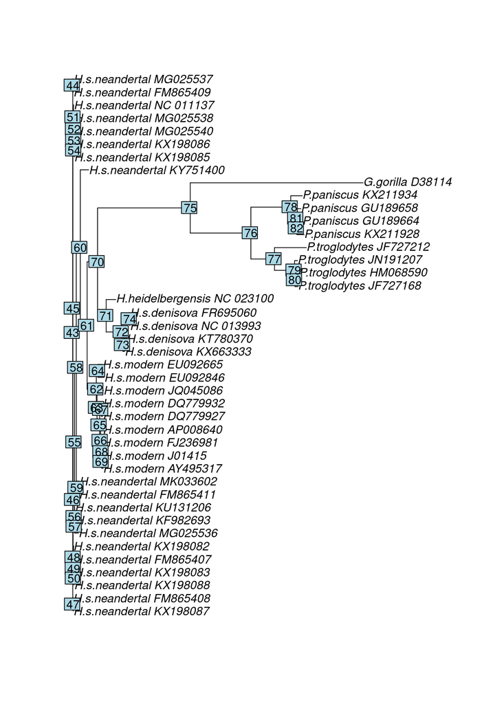

```r
plot(mt_nj)
nodelabels() # vemos que el nodelabel nos pone los nombres a los nodos, y el nodo que separa al gorila del resto de chimpancés, que es el 75
```

```r
# entonces, podemos hacer:
mt_nj_rooted <- root(mt_nj, node = 75)
```

Otra forma de enraizar es utilizando un outgroup para que el enraizado no dependa de la numeración que hace el programa solo al enraizar como antes:

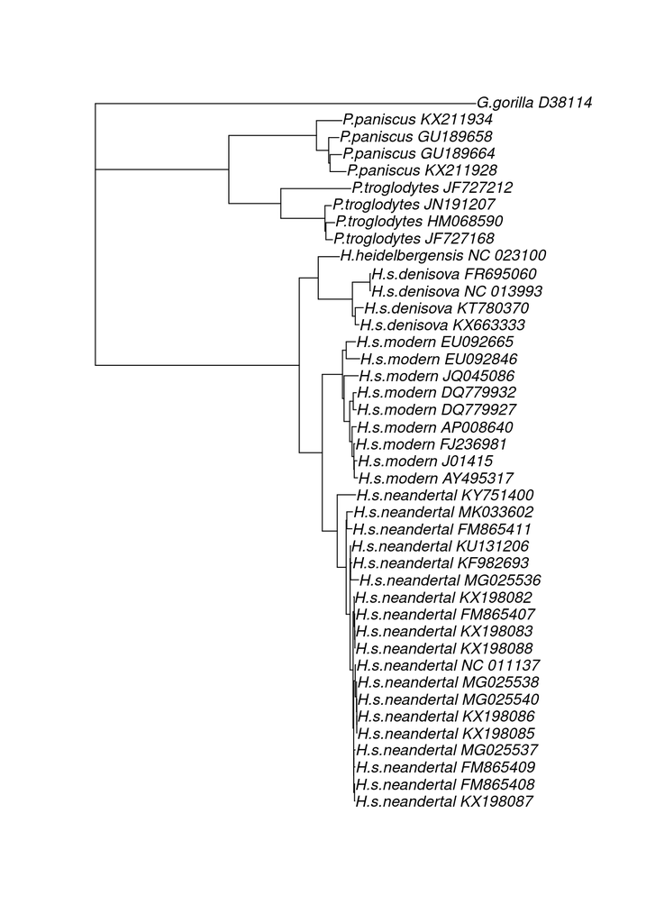

```r
enraizado <- root(mt_nj, outgroup = 'G.gorilla_D38114')
plot(enraizado)
```

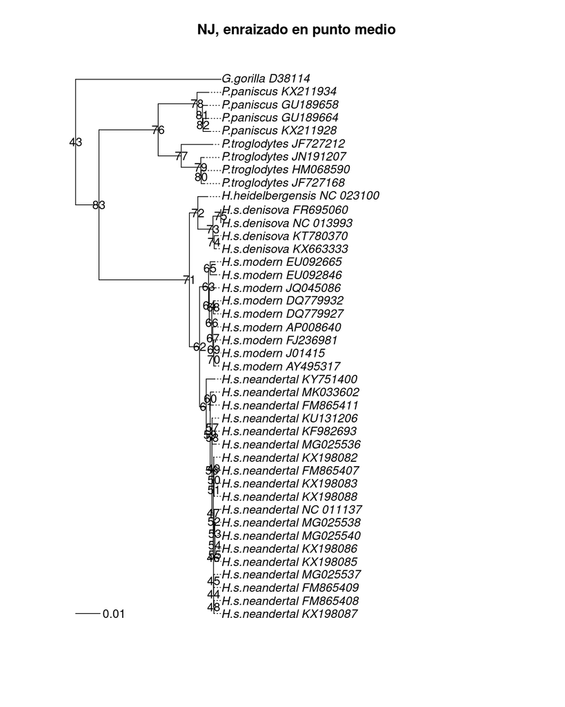

```r
mt_nj_rooted <- midpoint(mt_nj)
plot(mt_nj_rooted, align.tip.label = TRUE, main = 'NJ, enraizado en punto medio')
nodelabels(frame = 'none')
add.scale.bar()
```

## Con datación de hojas

Añadir fechas a cada especie (tip dating):valor 0 a todas las secuencias contemporáneas y valores negativos, en años, a las secuencias arcaicas. Se las doy manualmente, en orden de aparición en el arbol mt_nj. Podemos ver el orden en el que aparecen las puntas de los árboles poniendo en la consola de r “mt_nj$tip.label”

```r
fechas <- c(0, 0, 0, 0, 0, 0, 0, 0, 0,
              -400000,
              -39000, -50000, -110000, -110000,
              -39820, -40096, -38515, -38310, -39000, -40000, -41210,
              -42430, -42540, -43230, -43780, -44290, -44770, -49000,
              -50000, -82752, -65000, -122287, -110450,
              0, 0, 0, 0, 0, 0, 0, 0, 0)
setNames(fechas, names(mtdna))
```

```
           G.gorilla_D38114      P.troglodytes_JF727212
                          0                           0
     P.troglodytes_JN191207      P.troglodytes_JF727168
                          0                           0
     P.troglodytes_HM068590         P.paniscus_KX211934
                          0                           0
        P.paniscus_KX211928         P.paniscus_GU189658
                          0                           0
        P.paniscus_GU189664 H.heidelbergensis_NC_023100
                          0                     -400000
     H.s.denisova_NC_013993       H.s.denisova_FR695060
                     -39000                      -50000
      H.s.denisova_KX663333       H.s.denisova_KT780370
                    -110000                     -110000
    H.s.neandertal_KX198085     H.s.neandertal_KX198086
                     -39820                      -40096
    H.s.neandertal_MG025538    H.s.neandertal_NC_011137
                     -38515                      -38310
    H.s.neandertal_FM865409     H.s.neandertal_FM865407
                     -39000                      -40000
    H.s.neandertal_KX198088     H.s.neandertal_KX198083
                     -41210                      -42430
    H.s.neandertal_MG025540     H.s.neandertal_MG025536
                     -42540                      -43230
    H.s.neandertal_MG025537     H.s.neandertal_KX198087
                     -43780                      -44290
    H.s.neandertal_KX198082     H.s.neandertal_FM865408
                     -44770                      -49000
    H.s.neandertal_KU131206     H.s.neandertal_KF982693
                     -50000                      -82752
    H.s.neandertal_FM865411     H.s.neandertal_KY751400
                     -65000                     -122287
    H.s.neandertal_MK033602         H.s.modern_EU092846
                    -110450                           0
        H.s.modern_EU092665         H.s.modern_JQ045086
                          0                           0
        H.s.modern_DQ779927         H.s.modern_DQ779932
                          0                           0
        H.s.modern_AP008640         H.s.modern_AY495317
                          0                           0
          H.s.modern_J01415         H.s.modern_FJ236981
                          0                           0
```

A continuación se escoge la posición de la raíz que optimiza la regresión entre distancia de raíz a puntas y edades de las puntas:

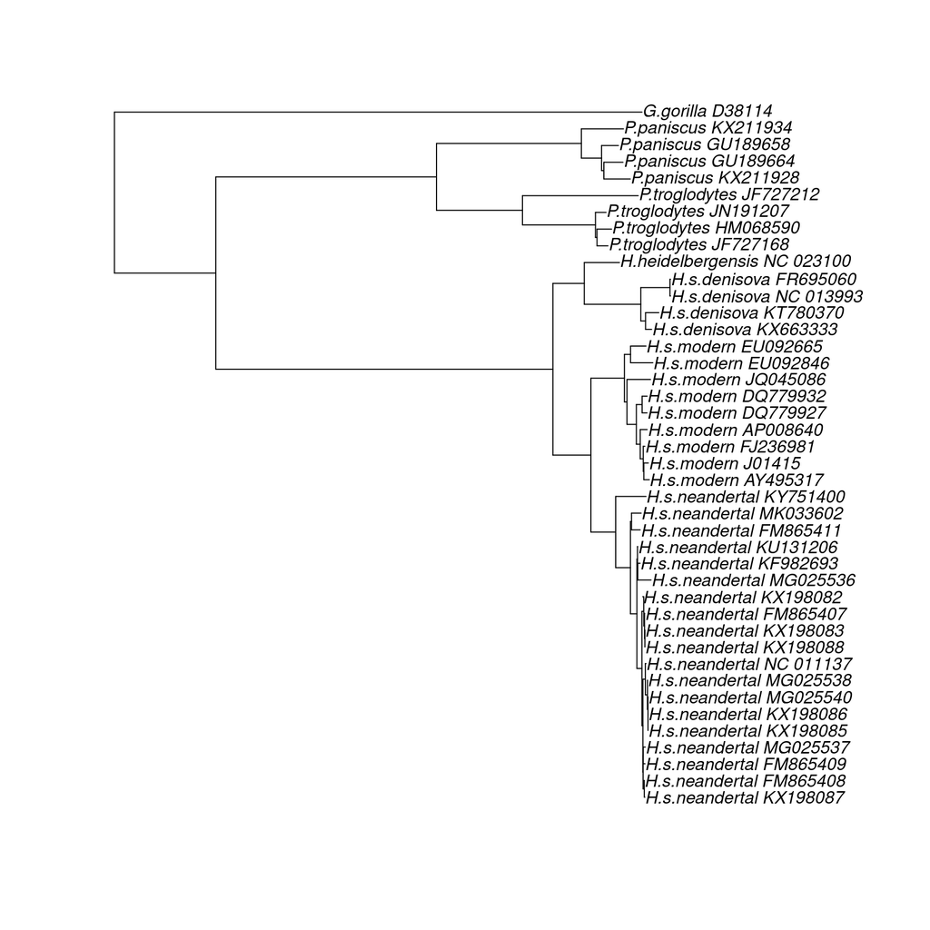

```r
mt_nj_rtt <- rtt(mt_nj, tip.dates = fechas, objective = 'rms')
# rtt es añadir raíz por la regresión root-to-tip: pone la raíz al árbol con especies datadas, en la posssición más compatible asumiendo un reloj molecular estricto.
# elige la raíz que pone mejor correlación entre las distancias y las puntas
plot(mt_nj_rtt)
```

- ¿Se corresponden bien las distancias evolutivas estimadas con las dataciones? ¿Qué secuencias crees que se ajustan menos a su supuesta edad? ¿Qué razones puede haber para que la edad de una secuencia no se corresponda con la cantidad de cambios que ha acumulado? Vemos que algunas ramas de chimpancés quedan atrás que los denisovanos, y esto no es lo que esperaríamos ver. De hecho, algunos denisovanos pasan por delante de algunos humanos. Los denisovanos son los que menos se corresponden con su edad. Puede que sea porque la datación de estos individuos sea poco precisa, que tengan errores de datación y hayamos asumido que son más antiguos de lo que son. Estas secuencias además podrían tener cambios no por mutaciones ancestrales, sino por degradación del ADN desde que se depositó el fosil hasta que lo secuenciaron. p.e. puede ocurrir desaminación. Se supoen que hay métodos estadísticos para corregirlo, pero parece que estos denisovanos han acumulado más mutaciones que otros más actuales: errores de secuenciación o por degradación de DNA. Otra cosa a comprobar es ir a la tabla del apéndice y comprobar que no nos hayamos equivocado en la datación. Es obvio que se han acumulado más cambios en los denisovanos.

Las distancias estimadas no son exactas. Cuanto mayor es la distancia, mayor es el error en la estimación.

##Distancias Hemos creado “distancias” antes. Para conocer la cantidad estimada de cambios entre los cromosomas mitocondriales, podemos obtener este parámetro en forma de matriz::

```r
distMat <- as.matrix(distancias)
```

Aprovechando que los nombres de las secuencias tienen una estructura coherente, podemos usar startsWith() para seleccionar a los humanos modernos o a los neandertales, etc.:

```r
# Esto son vectores lógicos que podemos usar después para seleccionar filas
# y columnas de la matriz de distancias.
modernos     <- startsWith(colnames(distMat), 'H.s.modern')
neandertales <- startsWith(colnames(distMat), 'H.s.neandertal')
denisovanos  <- startsWith(colnames(distMat), 'H.s.denisova')
chimpances   <- startsWith(colnames(distMat), 'P.troglodytes')
bonobos      <- startsWith(colnames(distMat), 'P.paniscus')
```

La distancia estimada media entre humanos y neandertales se puede obtener como:

```r
mean(distMat[modernos, neandertales])
```

```
[1] 0.01214282
```

- Calcula las distancias medias entre todos los grupos. con distMat[, ] seleccionamos primero filas y despues columnas de los componentes de la matriz.

```r
z <- mean(distMat[modernos, neandertales])
z
```

```
[1] 0.01214282
```

```r
mean(distMat[modernos, denisovanos])
```

```
[1] 0.02250501
```

```r
a <- mean(distMat[modernos, chimpances])
a
```

```
[1] 0.09104153
```

```r
mean(distMat[modernos, bonobos])
```

```
[1] 0.09239182
```

```r
mean(distMat[neandertales, denisovanos])
```

```
[1] 0.02201398
```

```r
mean(distMat[neandertales, chimpances])
```

```
[1] 0.09041225
```

```r
mean(distMat[neandertales, bonobos])
```

```
[1] 0.09089352
```

```r
mean(distMat[denisovanos, chimpances])
```

```
[1] 0.09129525
```

```r
mean(distMat[denisovanos, bonobos])
```

```
[1] 0.09297814
```

```r
mean(distMat[chimpances, bonobos])
```

```
[1] 0.04059035
```

- ¿Cuántas veces mayor es la distancia entre humanos y chimpancés que entre humanos y neandertales?

```r
a/z
```

```
[1] 7.497561
```

Hay 7.5 veces más distancia entre humanos y chimpancés que con los neandertales. - ¿Cómo calcularías la distancia media entre dos secuencias de humanos modernos?

```r
z <- distMat[modernos, modernos]
z[z == 0] <- NA
mean(z, na.rm = TRUE)
```

```
[1] 0.003747961
```

Podemos conocer las distancias que separan unas especies de otras con cophenetic poniendo:

```r
distCofen <- cophenetic(mt_nj_rooted)
```

- ¿Cuánto se parecen las distancias estimadas a las distancias cofenéticas? Las estimadas las vemos en distMat, y ls cofenéticas en distCofen. Son muy similares. Podemos compararlas mejor con:

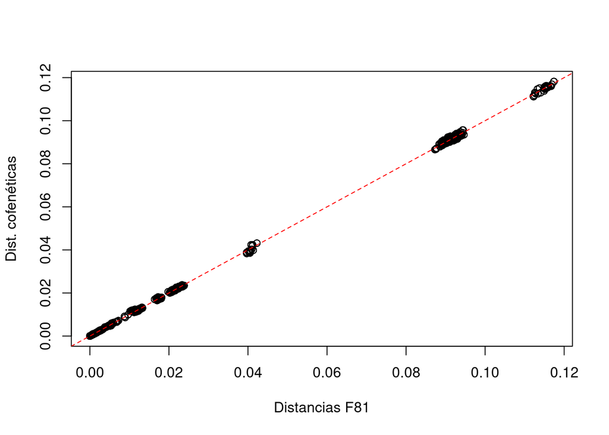

```r
plot(distMat, distCofen, xlab = 'Distancias F81', ylab = 'Dist. cofenéticas')
abline(a = 0, b = 1, col = 'red', lty = 2)
```

##Limpieza o filtrado de alineamiento

```r
crudas <- dist.dna(as.DNAbin(mtdna), model = 'raw')
crudas <- as.matrix(crudas)
identicas <- which(crudas == 0 & lower.tri(crudas), arr.ind = TRUE)
# posiciones de la semimatriz inferior donde las distancias son 0:
identicas
```

```
                        row col
H.s.neandertal_KX198086  16  15
H.s.neandertal_MG025540  23  15
H.s.neandertal_MG025540  23  16
H.s.neandertal_KX198088  21  20
H.s.neandertal_KX198083  22  20
H.s.neandertal_KX198082  27  20
H.s.neandertal_KX198083  22  21
H.s.neandertal_KX198082  27  21
H.s.neandertal_KX198082  27  22
```

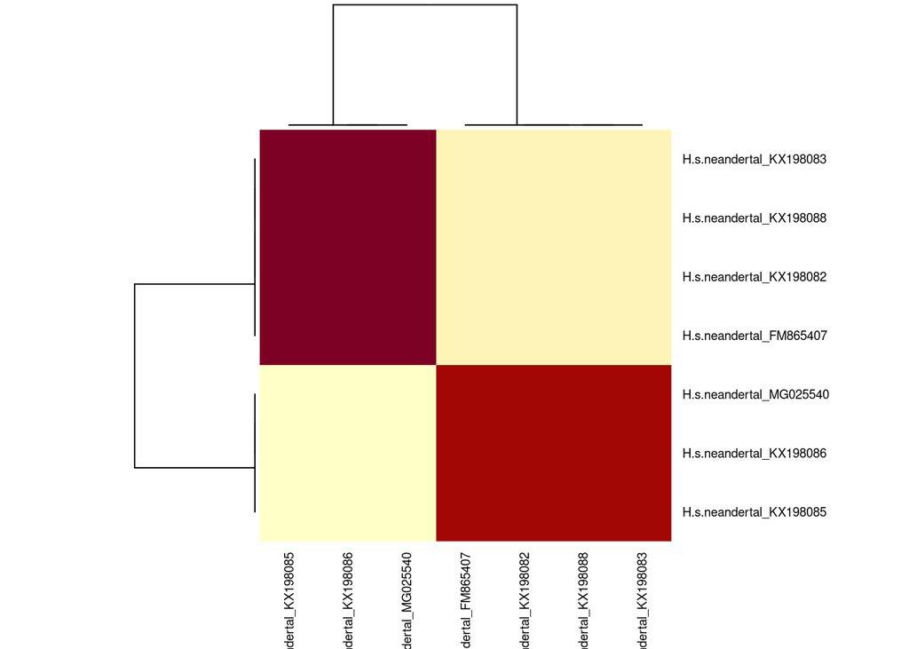

```r
repetidas <- unique(c(identicas[, 'row'], identicas[, 'col']))
heatmap(crudas[repetidas, repetidas], cexRow = 0.7, cexCol = 0.7)
```

```r
# La exclamación ("!") invierte el valor lógico de lo que la sigue.
# La función "grepl()" produce un vector lógico con "TRUE" donde los nombres
# de las secuencias contienen alguna de esas palabras.
mtdna37 <- mtdna[! grepl('(KX198085|KX198086|KX198082|KX198088|KX198083)',
                         names(mtdna)), ]
mtdna37
```

```
37 sequences with 16603 character and 974 different site patterns.
The states are a c g t
```

- ¿Serías capaz de crear otro conjunto de datos, mtdna28, que sólo contenga secuencias del género Homo?

```r
# con grepl estamos seleccionando que nos muestre los nombres de los componentes de la matriz mtdna37 que empiecen (^) por H.
mtdna28 <- mtdna37[grepl('^H.', names(mtdna37)), ]
```

para quitar la secuencia del gorila que es muy divergente:

```r
mtdna36 <- mtdna37[! startsWith(names(mtdna37), 'G.gorilla'),]
```

##Escoger el modelo de evolución molecular